# Indices of Biodiversity and Species Percent Cover from Vegetation Transect Data

UI Field Course at NGRREC 2023

2023-05-17

## Install and load libraries

R works with different packages that provide specific functionalities beyond what is offered from ‘base R’. In order to use the tools within a specific package, you must install and load the package within your current R session.

Here, we’re loading the packages, ‘tidyr’, ‘dplyr’ and ‘ggplot2’

tidyr and dplyr are both packages within the tidyverse family. You can read more about tidyverse here: https://www.tidyverse.org/

ggplot2 is a package used to create flexible graphics with R.

```r
# load the packages we'll need to work with
library(ggplot2)
library(tidyr)
library(dplyr)
```

If this is your first time using these packages within R, you’ll need to install them by running the following commands:

*install.packages(‘ggplot2’)*

*install.packages(‘tidyr’)*

*install.packages(‘dplyr’)*

## Set working directory

The advantage of setting a working directory at the start is that you don’t have to define a full file path every time you read in a file, so long as it resides in the defined working directory.

```r
# Set working directory to the folder that holds my data files
setwd("C:/Users/saweiss.LC/OneDrive - Lewis and Clark Community College/UI Field Course/UI-Field-Course-at-NGRREC/")
```

## Read in dataset

In order to read your data into R, you must use the proper function that will recognize the file format of your data file. Here, we are reading in a .csv file (stands for ‘comma separated values’), which is a common file format for storing large datasets.

*NOTE: All example data were made up for the purposes of demonstrating code

```r
veg <- read.csv("vegetation_example.csv")

# inspect the data
head(veg) # this allows you to inspect the first 6 rows of this data frame
```

```
##   Transect Azimuth Distance              Species Percent_Cover
## 1        1       0        5 Phalaris arundinacea            50
## 2        1       0        5               Allium             8
## 3        1       0        5             Solidago             4
## 4        1       0        5            Goldenrod             3
## 5        1       0        5                Carex            60
## 6        1       0       10 Phalaris arundinacea            20
```

## Calculating Indices of Biodiversity: Richness, Diversity, and Evenness

### Species Richness

Species richness equals the number of species observed at a site- here ‘site’ is going to be the quadrats along the transect.

$$R = s$$
Where s is the number of different species observed.

To count up the number of unique species in each quadrat, we are using the ‘group_by’ and ‘summarize’ functions from the ‘dplyr’ package. We are also using pipes (noted with ‘%>%’) to allow us to efficiently move the data through both functions in sequence.

```r
unique_veg <- unique(veg[,c("Distance", "Species")]) #list of unique species at each distance
richness <- unique_veg %>%
  group_by(Distance) %>% # designate the grouping variable(s)
  summarize(Richness = n()) # provide the formula, in this case, counting the rows (this is what 'n()' does)

richness # return the resulting data frame, which summarizes species richness at each quadrat along each transect
```

```
## # A tibble: 6 × 2
##   Distance Richness
##      <int>    <int>
## 1        5       11
## 2       10        7
## 3       15        5
## 4       25       11
## 5       35        8
## 6       45        8
```

### Species Diversity - Shannon-Wiener

A common measure of diversity used in ecology is the Shannon-Wiener Index (H’), calculated as:

$$H’ = -∑ (p_i * ln[p_i])$$

Where
$$p_i = n_i/N$$

n is the number of individuals of a given species and N is the total number of individuals in a sample.

In this case, we collected percent cover data, so n is the percent cover of a given species, and N is the total percent cover of all individuals at the site.

```r
avg_cov <- veg %>%
  group_by(Distance, Species) %>% # designate the grouping variable(s)
  summarize(AvgCov = mean(Percent_Cover))

diversity_table <- avg_cov %>%
  group_by(Distance) %>%
  summarize(N = sum(AvgCov), # provide formula for calculating N (overall sum of individuals)
            pi = AvgCov/sum(AvgCov),
            lnpi = log(pi),
            Shannon = -(pi*lnpi))

diversity_table # return the summarized data
```

```
## # A tibble: 50 × 5
## # Groups:   Distance [6]
##    Distance     N     pi  lnpi Shannon
##       <int> <dbl>  <dbl> <dbl>   <dbl>
##  1        5  164. 0.0335 -3.40  0.114
##  2        5  164. 0.0122 -4.41  0.0537
##  3        5  164. 0.0304 -3.49  0.106
##  4        5  164. 0.320  -1.14  0.365
##  5        5  164. 0.0913 -2.39  0.219
##  6        5  164. 0.0609 -2.80  0.170
##  7        5  164. 0.0183 -4.00  0.0731
##  8        5  164. 0.122  -2.11  0.256
##  9        5  164. 0.0731 -2.62  0.191
## 10        5  164. 0.198  -1.62  0.321
## # … with 40 more rows
```

```r
# finish calculating overall Shannon's index for the site by distance
diversity <- diversity_table %>%
  group_by(Distance) %>%
  summarize(Shannon=sum(Shannon))

diversity # return the summarized data
```

```
## # A tibble: 6 × 2
##   Distance Shannon
##      <int>   <dbl>
## 1        5    2.00
## 2       10    1.78
## 3       15    1.46
## 4       25    2.22
## 5       35    1.97
## 6       45    1.89
```

### Species Evenness

Evenness is a measure of how similar the abundances of different species are. E values can range from close to 0 (where most species are rare and just a few are abundant) to 1 (where species are equally abundant). Evenness is calculated using both H’ and R:

$$E = H’/ln(R)$$

To make use of both our diversity and richness data frames in this final calculation, we will join them together.

```r
bio_indices <- left_join(diversity, richness) # if not specified, will join based on commonly named variable(s). Here, those variables are 'Distance' and Transect'.

bio_indices # return the resulting joined data frame
```

```
## # A tibble: 6 × 3
##   Distance Shannon Richness
##      <int>   <dbl>    <int>
## 1        5    2.00       11
## 2       10    1.78        7
## 3       15    1.46        5
## 4       25    2.22       11
## 5       35    1.97        8
## 6       45    1.89        8
```

Now that we have a data frame with both H’ and R, we can calculate the variable ‘Evenness’.

Specific columns within a data set can be called on with the ‘$’ symbol, followed by the name of the column. You can perform calculations using the contents of specific columns in the data frame this way.

```r
bio_indices$Evenness <- bio_indices$Shannon/log(bio_indices$Richness) # assigning the resulting evenness calculations to a new variable called 'Evenness'

bio_indices # return the updated data frame
```

```
## # A tibble: 6 × 4
##   Distance Shannon Richness Evenness
##      <int>   <dbl>    <int>    <dbl>
## 1        5    2.00       11    0.834
## 2       10    1.78        7    0.917
## 3       15    1.46        5    0.908
## 4       25    2.22       11    0.924
## 5       35    1.97        8    0.946
## 6       45    1.89        8    0.907
```

## Graph the Results

Let’s graph these indices looking at how they vary based on Distance. To do this, we’ll use the ggplot2 package, which is a commonly used R graphing package, that allows for lots of flexible formatting options.

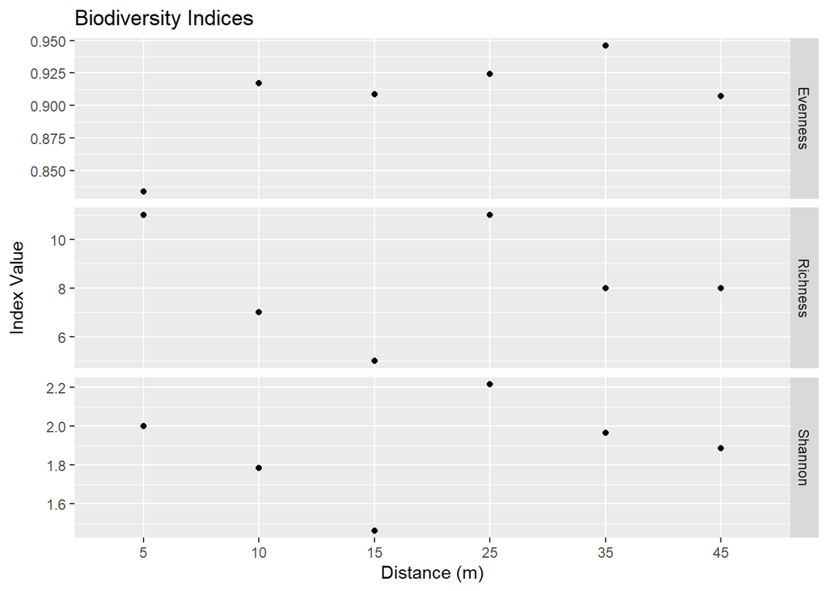

```r
# first, we need to transform the data such that each observed index value is its own row, and we move the index names to one column. This is known as a 'long' format data frame
bio_indices_long <- pivot_longer(bio_indices, cols = Shannon:Evenness, names_to = "Index") # cols argument is the first:last colummns for the indices.

# Create a plot of all three indices
bioplot <- ggplot(data=bio_indices_long, aes(x=as.factor(Distance), y=value)) + # indicates the dataframe to use, the x axis variable (Site), y axis variable (value), and grouping variable (Site) for colors
  geom_point() + # specifies type of plot
  facet_grid(rows=vars(Index), scales = "free_y") + # separates each index to its own plot in its own row
  ggtitle("Biodiversity Indices") + # title
  xlab("Distance (m)") + # x axis label
  ylab("Index Value") #y axis label

bioplot
```

## Average and Relative Percent Cover by Species

We also collected percent cover data within our vegetation quadrats, so let’s take a look at some species-specific patterns. We’ll return to our original data frame, *veg*.

```r
# We'll want to add in some 0 values to account for not every species being in every quadrat. To do that we'll transform the data frame into a 'wide' format, so each species now has its own column

veg_wide <- pivot_wider(veg, id_cols = c(Transect, Distance), names_from = Species, values_from = Percent_Cover, values_fill = 0) # we make sure to set values_fill equal to zero so that non-observations are counted as '0'.
head(veg_wide) # inspect what the wide format data frame looks like
```

```
## # A tibble: 6 × 18
##   Transect Distance Phalaris…¹ Allium Solid…² Golde…³ Carex Arabis Humul…⁴ Aster
##      <int>    <int>      <int>  <int>   <int>   <int> <int>  <int>   <int> <int>
## 1        1        5         50      8       4       3    60      0       0     0
## 2        1       10         20      6       7       0    30     10       0     0
## 3        1       25         15     12       0       0    14      0      30     4
## 4        1       35         10      6       5       0     0      0      25     6
## 5        1       45          0      0       2       0     0      0       0     7
## 6        2        5          0      0       3       0    45      0       0     0
## # … with 8 more variables: `Rumex crispum` <int>, `Acer negundo` <int>,
## #   `Populus deltoides` <int>, `Leersia Oryzoides` <int>,
## #   `Oxalis stricta` <int>, `Eleocharis palustris` <int>, Geranium <int>,
## #   `Stellaria media` <int>, and abbreviated variable names
## #   ¹`Phalaris arundinacea`, ²Solidago, ³Goldenrod, ⁴`Humulus japonicus`
```

```r
# we can now move back to long format to finish summarizing. You should notice that our new data frame is longer than the original 'veg' data frame since we have now added in those zero observations
veg_wzeros <- pivot_longer(veg_wide, cols = `Phalaris arundinacea`:`Stellaria media`, names_to = "Species", values_to = "Percent_Cover") # cols argument is the first:last species columns. I had to use `` around the names because the names include spaces.

head(veg_wzeros)
```

```
## # A tibble: 6 × 4
##   Transect Distance Species              Percent_Cover
##      <int>    <int> <chr>                        <int>
## 1        1        5 Phalaris arundinacea            50
## 2        1        5 Allium                           8
## 3        1        5 Solidago                         4
## 4        1        5 Goldenrod                        3
## 5        1        5 Carex                           60
## 6        1        5 Arabis                           0
```

Now we can summarize the average and relative percent cover by species.

Relative percent cover is the percent cover of a particular species out of total plant cover

```r
# what is the total percent cover across all quadrats?
tot_cover <- sum(veg_wzeros$Percent_Cover) # assign the value to an object so we can reference later

# summarizing average and relative percent covers by species across all plots
avg_perc_cov <- veg_wzeros %>%
  group_by(Species) %>% # this time our grouping variable is "Species"
  summarize(Avg_Perc_Cover = mean(Percent_Cover), # add new variable for the average percent cover
            Rel_Perc_Cover = (sum(Percent_Cover)/tot_cover)*100)  # add new variable for the relative percent cover

head(avg_perc_cov)
```

```
## # A tibble: 6 × 3
##   Species              Avg_Perc_Cover Rel_Perc_Cover
##   <chr>                         <dbl>          <dbl>
## 1 Acer negundo                   3.85           7.08
## 2 Allium                         4.4            8.09
## 3 Arabis                         1.35           2.48
## 4 Aster                          4.35           8.00
## 5 Carex                          7.45          13.7
## 6 Eleocharis palustris           1.75           3.22
```

It’s sometimes useful to save your resulting data frame from a particular analysis. Let’s save our percent cover data frame.

```r
# saving as a csv to my working directory
write.csv(avg_perc_cov, "Percent_Cover_by_Species.csv")
```